# EDA

```python
import numpy as np # linear algebra
import pandas as pd # data processing, CSV file I/O (e.g. pd.read_csv)
import os
from glob import glob
%matplotlib inline
import matplotlib.pyplot as plt
import seaborn as sns

from skimage import io
##Import any other packages you may need here
```

EDA is open-ended, and it is up to you to decide how to look at different ways to slice and dice your data. A good starting point is to look at the requirements for the FDA documentation in the final part of this project to guide (some) of the analyses you do.

This EDA should also help to inform you of how pneumonia looks in the wild. E.g. what other types of diseases it's commonly found with, how often it is found, what ages it affects, etc.

Note that this NIH dataset was not specifically acquired for pneumonia. So, while this is a representation of 'pneumonia in the wild,' the prevalence of pneumonia may be different if you were to take only chest x-rays that were acquired in an ER setting with suspicion of pneumonia.

Perform the following EDA:

- The patient demographic data such as gender, age, patient position,etc. (as it is available)
- The x-ray views taken (i.e. view position)
- The number of cases including:
  - number of pneumonia cases,
  - number of non-pneumonia cases
- The distribution of other diseases that are comorbid with pneumonia
- Number of disease per patient
- Pixel-level assessments of the imaging data for healthy & disease states of interest (e.g. histograms of intensity values) and compare distributions across diseases.

Note: use full NIH data to perform the first a few EDA items and use `sample_labels.csv` for the pixel-level assassements.

Also, **describe your findings and how will you set up the model training based on the findings.**

```python
## Below is some helper code to read data for you.
## Load NIH data
all_xray_df = pd.read_csv('/data/Data_Entry_2017.csv')
all_xray_df.sample(3)
```

|  | Image Index | Finding Labels | Follow-up # | Patient ID | Patient Age | Patient Gender | View Position | OriginalImage[Width | Height] | OriginalImagePixelSpacing[x | y] | Unnamed: 11 |
| --- | --- | --- | --- | --- | --- | --- | --- | --- | --- | --- | --- | --- |
| 33329 | 00008741_004.png | No Finding | 4 | 8741 | 33 | F | AP | 2500 | 2048 | 0.168 | 0.168 | NaN |
| 104980 | 00028166_001.png | No Finding | 1 | 28166 | 19 | F | AP | 3056 | 2544 | 0.139 | 0.139 | NaN |
| 17655 | 00004755_017.png | No Finding | 17 | 4755 | 40 | F | AP | 2500 | 2048 | 0.168 | 0.168 | NaN |

```python
all_xray_df['Unnamed: 11'].value_counts()
```

```
Series([], Name: Unnamed: 11, dtype: int64)
```

```python
all_xray_df.index
```

```
RangeIndex(start=0, stop=112120, step=1)
```

```python
## Load 'sample_labels.csv' data for pixel level assessments
sample_df = pd.read_csv('sample_labels.csv')
sample_df.sample(3)
```

|  | Image Index | Finding Labels | Follow-up # | Patient ID | Patient Age | Patient Gender | View Position | OriginalImageWidth | OriginalImageHeight | OriginalImagePixelSpacing_x | OriginalImagePixelSpacing_y |
| --- | --- | --- | --- | --- | --- | --- | --- | --- | --- | --- | --- |
| 3705 | 00018187_052.png | Consolidation\|Edema | 52 | 18187 | 032Y | F | AP | 2500 | 2048 | 0.168 | 0.168 |
| 4249 | 00020945_031.png | No Finding | 31 | 20945 | 034Y | M | PA | 2992 | 2991 | 0.143 | 0.143 |
| 3801 | 00018663_005.png | Mass | 5 | 18663 | 031Y | F | AP | 2500 | 2048 | 0.168 | 0.168 |

```python
len(sample_df)
```

```
5606
```

### Exploratory Data Analysis

```python
(all_xray_df['Patient Age'].values > 120).sum()
```

```
16
```

So I am subtracting 100 from age values more than 120, as I am assuming it is input mistake

```python
all_xray_df['Patient Age'] = all_xray_df['Patient Age'].apply(lambda x: int(str(x)[-2:]) if x > 120 else x)
```

```python
all_xray_df['Patient Age'].min()
```

```
1
```

```python
all_xray_df['Patient Age'].max()
```

```
95
```

##### Extract penumoinia cases df

```python
all_xray_df['pneumonia'] = all_xray_df.apply(lambda x: 1 if 'Pneumonia' in x['Finding Labels'] else 0, axis=1)
```

```python
pneu_cases = all_xray_df[all_xray_df['pneumonia'] == 1]
```

```python
pneu_cases
```

|  | Image Index | Finding Labels | Follow-up # | Patient ID | Patient Age | Patient Gender | View Position | OriginalImage[Width | Height] | OriginalImagePixelSpacing[x | y] | Unnamed: 11 | pneumonia |
| --- | --- | --- | --- | --- | --- | --- | --- | --- | --- | --- | --- | --- | --- |
| 48 | 00000013_010.png | Effusion\|Pneumonia\|Pneumothorax | 10 | 13 | 60 | M | AP | 3056 | 2544 | 0.139 | 0.139 | NaN | 1 |
| 126 | 00000032_012.png | Atelectasis\|Consolidation\|Edema\|Pneumonia | 12 | 32 | 55 | F | AP | 2500 | 2048 | 0.168 | 0.168 | NaN | 1 |
| 253 | 00000056_000.png | Nodule\|Pneumonia | 0 | 56 | 76 | M | PA | 2500 | 2048 | 0.168 | 0.168 | NaN | 1 |
| 276 | 00000061_012.png | Edema\|Effusion\|Infiltration\|Pleural_Thickening... | 12 | 61 | 77 | M | AP | 3056 | 2544 | 0.139 | 0.139 | NaN | 1 |
| 279 | 00000061_015.png | Pneumonia | 15 | 61 | 77 | M | AP | 3056 | 2544 | 0.139 | 0.139 | NaN | 1 |
| ... | ... | ... | ... | ... | ... | ... | ... | ... | ... | ... | ... | ... | ... |
| 111557 | 00030536_007.png | Atelectasis\|Consolidation\|Pneumonia | 7 | 30536 | 56 | F | AP | 3056 | 2544 | 0.139 | 0.139 | NaN | 1 |
| 111627 | 00030570_001.png | Edema\|Infiltration\|Pneumonia | 1 | 30570 | 29 | F | AP | 3056 | 2544 | 0.139 | 0.139 | NaN | 1 |
| 111767 | 00030621_002.png | Pneumonia | 2 | 30621 | 22 | F | AP | 3056 | 2544 | 0.139 | 0.139 | NaN | 1 |
| 111845 | 00030637_016.png | Consolidation\|Pneumonia | 16 | 30637 | 48 | M | AP | 3056 | 2544 | 0.139 | 0.139 | NaN | 1 |
| 112115 | 00030801_001.png | Mass\|Pneumonia | 1 | 30801 | 39 | M | PA | 2048 | 2500 | 0.168 | 0.168 | NaN | 1 |

1431 rows × 13 columns

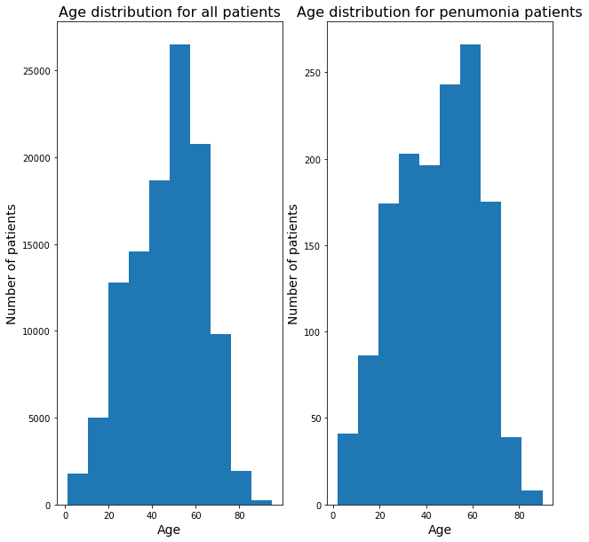

```python
fig, m_axs = plt.subplots(1,2, figsize = (10, 10))
m_axs = m_axs.flatten()

m_axs[0].hist(all_xray_df['Patient Age'].values)
m_axs[0].set_title('Age distribution for all patients', fontsize=16)
m_axs[0].set_xlabel('Age', fontsize=14)
m_axs[0].set_ylabel('Number of patients', fontsize=14)
m_axs[1].hist(pneu_cases['Patient Age'].values)
m_axs[1].set_title('Age distribution for penumonia patients', fontsize=16)
m_axs[1].set_xlabel('Age', fontsize=14)
m_axs[1].set_ylabel('Number of patients', fontsize=14)
```

#### Bar plot for gender data

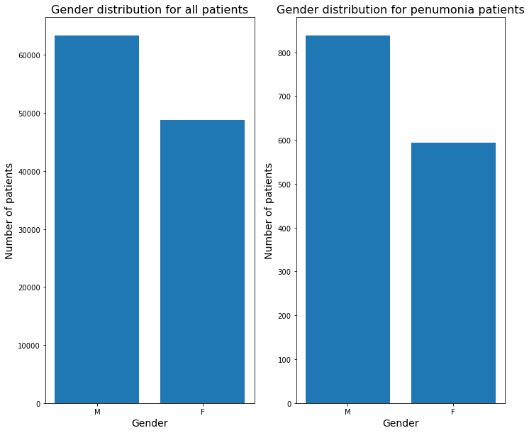

```python
fig, m_axs = plt.subplots(1,2, figsize = (10, 10))
m_axs = m_axs.flatten()

all_males = all_xray_df['Patient Gender'].value_counts().get('M')
all_females = all_xray_df['Patient Gender'].value_counts().get('F')
m_axs[0].bar(all_xray_df['Patient Gender'].value_counts().keys(), [all_males, all_females])
m_axs[0].set_title('Gender distribution for all patients', fontsize=16)
m_axs[0].set_xlabel('Gender', fontsize=14)
m_axs[0].set_ylabel('Number of patients', fontsize=14)
males = pneu_cases['Patient Gender'].value_counts().get('M')
females = pneu_cases['Patient Gender'].value_counts().get('F')
m_axs[1].bar(pneu_cases['Patient Gender'].value_counts().keys(), [males, females])
m_axs[1].set_title('Gender distribution for penumonia patients', fontsize=16)
m_axs[1].set_xlabel('Gender', fontsize=14)
m_axs[1].set_ylabel('Number of patients', fontsize=14)
plt.subplots_adjust(left=1.25, right=2.15)
```

```python
all_xray_df['View Position'].value_counts()
```

```
PA    67310
AP    44810
Name: View Position, dtype: int64
```

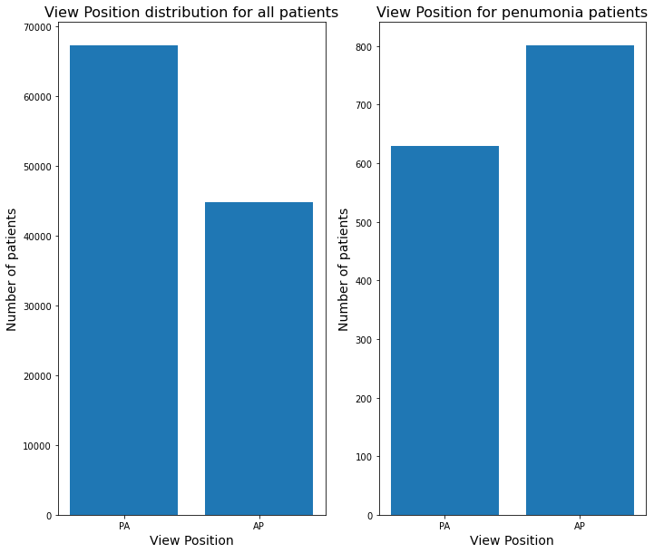

```python
fig, m_axs = plt.subplots(1,2, figsize = (10, 10))
m_axs = m_axs.flatten()

all_PA = all_xray_df['View Position'].value_counts().get('PA')
all_AP = all_xray_df['View Position'].value_counts().get('AP')
m_axs[0].bar(all_xray_df['View Position'].value_counts().keys(), [all_PA, all_AP])
m_axs[0].set_title('View Position distribution for all patients', fontsize=16)
m_axs[0].set_xlabel('View Position', fontsize=14)
m_axs[0].set_ylabel('Number of patients', fontsize=14)
PA = pneu_cases['View Position'].value_counts().get('PA')
AP = pneu_cases['View Position'].value_counts().get('AP')
m_axs[1].bar(['PA', 'AP'], [PA, AP])
m_axs[1].set_title('View Position for penumonia patients', fontsize=16)
m_axs[1].set_xlabel('View Position', fontsize=14)
m_axs[1].set_ylabel('Number of patients', fontsize=14)
plt.subplots_adjust(left=1.25, right=2.15)
```

#### Bar plot for view position data

```python
pneu_cases['View Position'].value_counts()
```

```
AP    801
PA    630
Name: View Position, dtype: int64
```

### Visualising the number of cases availabe in the data it two categroies: pneumonia and non-pneumonia

```python
all_cases = len(all_xray_df['Finding Labels'])
all_cases
```

```
112120
```

```python
def count_pneu(all_cases):
    pneu_comorbid = []
    count = 0
    for case in all_cases:
        if 'Pneumonia' in case:
            count+=1
            pneu_comorbid.extend(case.split('|'))
    return (count, pneu_comorbid)
```

```python
pneu_cases, comorbid = count_pneu(all_xray_df['Finding Labels'])
pneu_cases
```

```
1431
```

```python
cases_ser = pd.Series([1431, 112120 - 1431], index=['Pneumonia', 'non-Pneumonia'])
cases_ser
```

```
Pneumonia          1431
non-Pneumonia    110689
dtype: int64
```

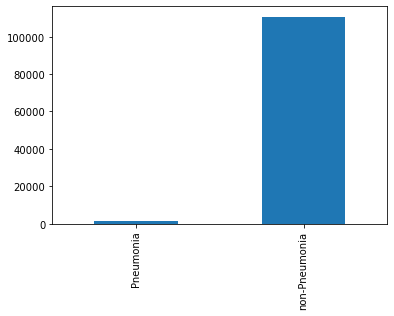

```python
cases_ser.plot(kind='bar')
```

### The distribution of other diseases that are comorbid with pneumonia

```python
unique = list(set(comorbid))
```

```python
unieque_dic = {}
for i in unique:
    unieque_dic[i] = comorbid.count(i)
```

```python
keys = unieque_dic.keys()
values = unieque_dic.values()

cases_dist = pd.Series(list(values), index=list(keys))
```

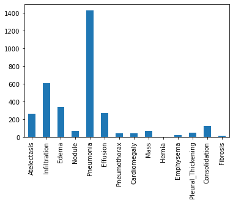

```python
cases_dist.plot(kind='bar')
```

### Number of disease per patient

```python
all_xray_df['diseases_number'] = all_xray_df.apply(lambda x: 0 if x['Finding Labels'] == 'No Finding' else len(x['Finding Labels'].split('|')), axis=1)
```

```python
all_xray_df
```

|  | Image Index | Finding Labels | Follow-up # | Patient ID | Patient Age | Patient Gender | View Position | OriginalImage[Width | Height] | OriginalImagePixelSpacing[x | y] | Unnamed: 11 | pneumonia | diseases_number |
| --- | --- | --- | --- | --- | --- | --- | --- | --- | --- | --- | --- | --- | --- | --- |
| 0 | 00000001_000.png | Cardiomegaly | 0 | 1 | 58 | M | PA | 2682 | 2749 | 0.143 | 0.143 | NaN | 0 | 1 |
| 1 | 00000001_001.png | Cardiomegaly\|Emphysema | 1 | 1 | 58 | M | PA | 2894 | 2729 | 0.143 | 0.143 | NaN | 0 | 2 |
| 2 | 00000001_002.png | Cardiomegaly\|Effusion | 2 | 1 | 58 | M | PA | 2500 | 2048 | 0.168 | 0.168 | NaN | 0 | 2 |
| 3 | 00000002_000.png | No Finding | 0 | 2 | 81 | M | PA | 2500 | 2048 | 0.171 | 0.171 | NaN | 0 | 0 |
| 4 | 00000003_000.png | Hernia | 0 | 3 | 81 | F | PA | 2582 | 2991 | 0.143 | 0.143 | NaN | 0 | 1 |
| ... | ... | ... | ... | ... | ... | ... | ... | ... | ... | ... | ... | ... | ... | ... |
| 112115 | 00030801_001.png | Mass\|Pneumonia | 1 | 30801 | 39 | M | PA | 2048 | 2500 | 0.168 | 0.168 | NaN | 1 | 2 |
| 112116 | 00030802_000.png | No Finding | 0 | 30802 | 29 | M | PA | 2048 | 2500 | 0.168 | 0.168 | NaN | 0 | 0 |
| 112117 | 00030803_000.png | No Finding | 0 | 30803 | 42 | F | PA | 2048 | 2500 | 0.168 | 0.168 | NaN | 0 | 0 |
| 112118 | 00030804_000.png | No Finding | 0 | 30804 | 30 | F | PA | 2048 | 2500 | 0.168 | 0.168 | NaN | 0 | 0 |
| 112119 | 00030805_000.png | No Finding | 0 | 30805 | 27 | M | PA | 2048 | 2500 | 0.171 | 0.171 | NaN | 0 | 0 |

112120 rows × 14 columns

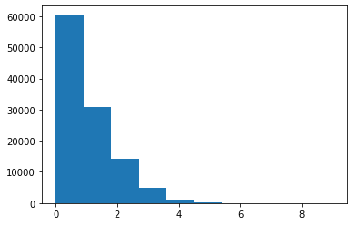

```python
plt.hist(all_xray_df['diseases_number'])
```

### Pixel-level assessments of the imaging data

```python
health_cases = sample_df[sample_df['Finding Labels'] == 'No Finding']
health_cases
```

|  | Image Index | Finding Labels | Follow-up # | Patient ID | Patient Age | Patient Gender | View Position | OriginalImageWidth | OriginalImageHeight | OriginalImagePixelSpacing_x | OriginalImagePixelSpacing_y |
| --- | --- | --- | --- | --- | --- | --- | --- | --- | --- | --- | --- |
| 2 | 00000017_001.png | No Finding | 1 | 17 | 077Y | M | AP | 2500 | 2048 | 0.168000 | 0.168000 |
| 6 | 00000042_002.png | No Finding | 2 | 42 | 071Y | M | AP | 3056 | 2544 | 0.139000 | 0.139000 |
| 7 | 00000057_001.png | No Finding | 1 | 57 | 071Y | M | AP | 3056 | 2544 | 0.139000 | 0.139000 |
| 9 | 00000061_019.png | No Finding | 19 | 61 | 077Y | M | AP | 3056 | 2544 | 0.139000 | 0.139000 |
| 12 | 00000080_005.png | No Finding | 5 | 80 | 067Y | F | PA | 1884 | 2021 | 0.194311 | 0.194311 |
| ... | ... | ... | ... | ... | ... | ... | ... | ... | ... | ... | ... |
| 5597 | 00030639_001.png | No Finding | 1 | 30639 | 061Y | M | AP | 3056 | 2544 | 0.139000 | 0.139000 |
| 5600 | 00030704_000.png | No Finding | 0 | 30704 | 052Y | F | PA | 2021 | 2021 | 0.194311 | 0.194311 |
| 5601 | 00030712_000.png | No Finding | 0 | 30712 | 058Y | M | PA | 2021 | 2021 | 0.194311 | 0.194311 |
| 5604 | 00030792_000.png | No Finding | 0 | 30792 | 010Y | F | PA | 1775 | 1712 | 0.194311 | 0.194311 |
| 5605 | 00030797_000.png | No Finding | 0 | 30797 | 024Y | M | PA | 2021 | 2021 | 0.194311 | 0.194311 |

3044 rows × 11 columns

```python
ten_health_cases = health_cases.sample(62)
ten_health_cases
```

|  | Image Index | Finding Labels | Follow-up # | Patient ID | Patient Age | Patient Gender | View Position | OriginalImageWidth | OriginalImageHeight | OriginalImagePixelSpacing_x | OriginalImagePixelSpacing_y |
| --- | --- | --- | --- | --- | --- | --- | --- | --- | --- | --- | --- |
| 5375 | 00029017_003.png | No Finding | 3 | 29017 | 067Y | M | AP | 3056 | 2544 | 0.139 | 0.139 |
| 4451 | 00022152_000.png | No Finding | 0 | 22152 | 027Y | F | PA | 2678 | 2769 | 0.143 | 0.143 |
| 4230 | 00020811_011.png | No Finding | 11 | 20811 | 028Y | M | AP | 3036 | 2544 | 0.139 | 0.139 |
| 3761 | 00018448_017.png | No Finding | 17 | 18448 | 042Y | M | PA | 2992 | 2991 | 0.143 | 0.143 |
| 3270 | 00016134_002.png | No Finding | 2 | 16134 | 043Y | M | AP | 2500 | 2048 | 0.168 | 0.168 |
| ... | ... | ... | ... | ... | ... | ... | ... | ... | ... | ... | ... |
| 2987 | 00014703_000.png | No Finding | 0 | 14703 | 063Y | M | PA | 2992 | 2991 | 0.143 | 0.143 |
| 1590 | 00008276_001.png | No Finding | 1 | 8276 | 057Y | M | AP | 2500 | 2048 | 0.168 | 0.168 |
| 4210 | 00020679_000.png | No Finding | 0 | 20679 | 069Y | M | PA | 2992 | 2991 | 0.143 | 0.143 |
| 4655 | 00023309_008.png | No Finding | 8 | 23309 | 067Y | M | AP | 3056 | 2544 | 0.139 | 0.139 |
| 4668 | 00023359_000.png | No Finding | 0 | 23359 | 061Y | M | PA | 2992 | 2991 | 0.143 | 0.143 |

62 rows × 11 columns

```python
images_list = []
for i in range(1,13):
    images_list.extend(glob('/data/images_0'+str("{0:0=2d}".format(i))+'/images/*'))
```

```python
def find_path(name):
    path=''
    for image in images_list:
        if image.endswith(name):
            path=image
    return path
```

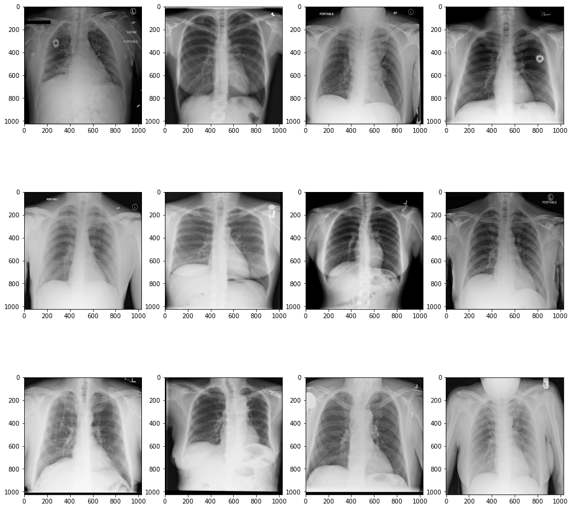

```python
fig, m_axs = plt.subplots(3,4, figsize = (16, 16))
m_axs = m_axs.flatten()
imgs = ten_health_cases['Image Index'][0:12]

for img, ax in zip(imgs, m_axs):
    path = find_path(img)
    if path != '':
        img = plt.imread(path)
        ax.imshow(img,cmap='gray')
```

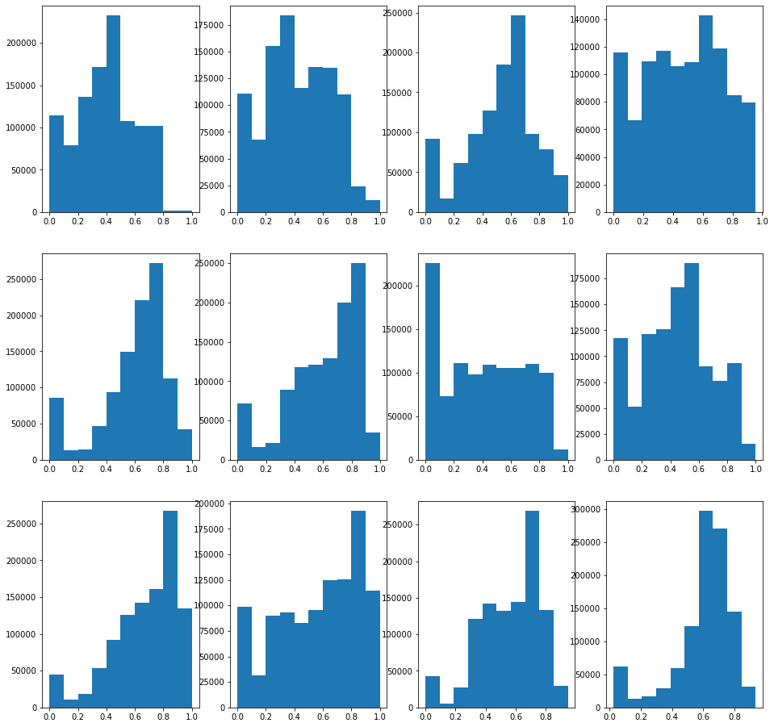

```python
fig, m_axs = plt.subplots(3,4, figsize = (16, 16))
m_axs = m_axs.flatten()

for img, ax in zip(imgs, m_axs):
    path = find_path(img)
    img = plt.imread(path)
    ax.hist(img.ravel())
plt.show()
```

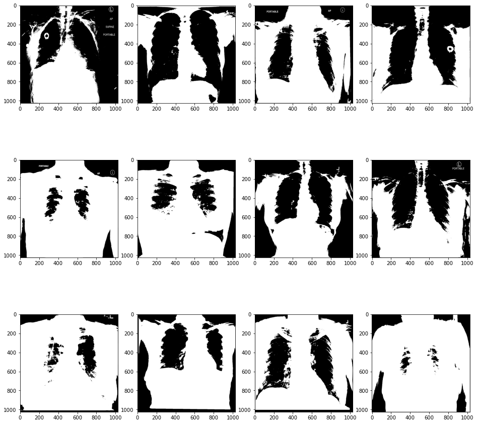

```python
threshold = 0.45
fig, m_axs = plt.subplots(3,4, figsize = (16, 16))
m_axs = m_axs.flatten()

for img, ax in zip(imgs, m_axs):
    path = find_path(img)
    img = plt.imread(path)
    bin_img = (img > threshold) * 255
    ax.imshow(bin_img ,cmap='gray')
```

#### I will chose sample method to get 62 images only to test the intensities as pneumonia images are only 62

```python
ten_health_cases.shape
```

```
(62, 11)
```

```python
healthy_intensities = []
for i in ten_health_cases['Image Index']:
    my_path = find_path(i)
    if my_path != '':
        img = plt.imread(my_path)
        img_mask = (img > threshold)
        healthy_intensities.extend(img[img_mask].tolist())
```

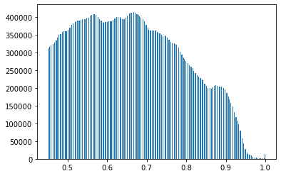

```python
x = plt.hist(healthy_intensities, bins=255)
```

```python
sample_df['Pneumonia'] = sample_df.apply(lambda x: 1 if 'Pneumonia' in x['Finding Labels'] else 0, axis=1)
```

```python
pneumonia_samples = sample_df[sample_df['Pneumonia'] == 1]
```

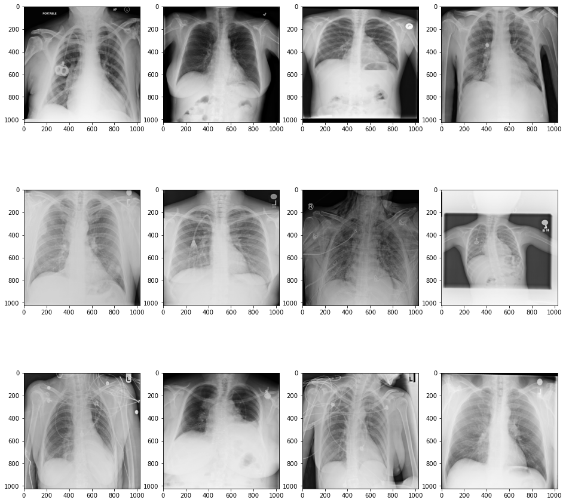

```python
fig, m_axs = plt.subplots(3,4, figsize = (16, 16))
m_axs = m_axs.flatten()
imgs = pneumonia_samples['Image Index'][0:12]

for img, ax in zip(imgs, m_axs):
    path = find_path(img)
    if path != '':
        img = plt.imread(path)
        ax.imshow(img,cmap='gray')
```

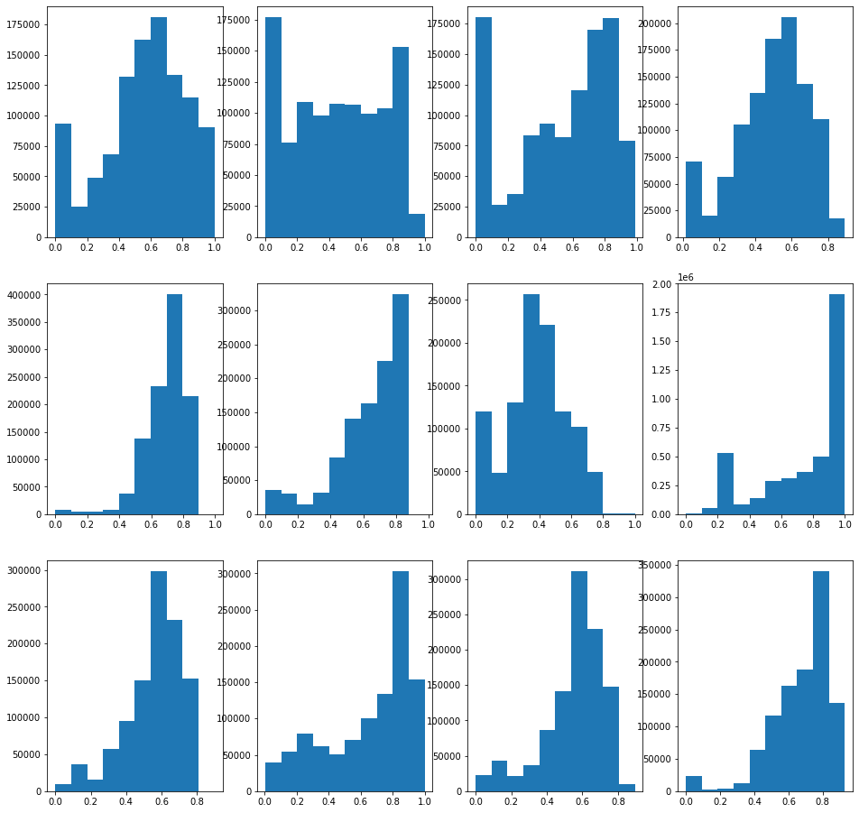

```python
fig, m_axs = plt.subplots(3,4, figsize = (16, 16))
m_axs = m_axs.flatten()

for img, ax in zip(imgs, m_axs):
    path = find_path(img)
    img = plt.imread(path)
    ax.hist(img.ravel())
plt.show()
```

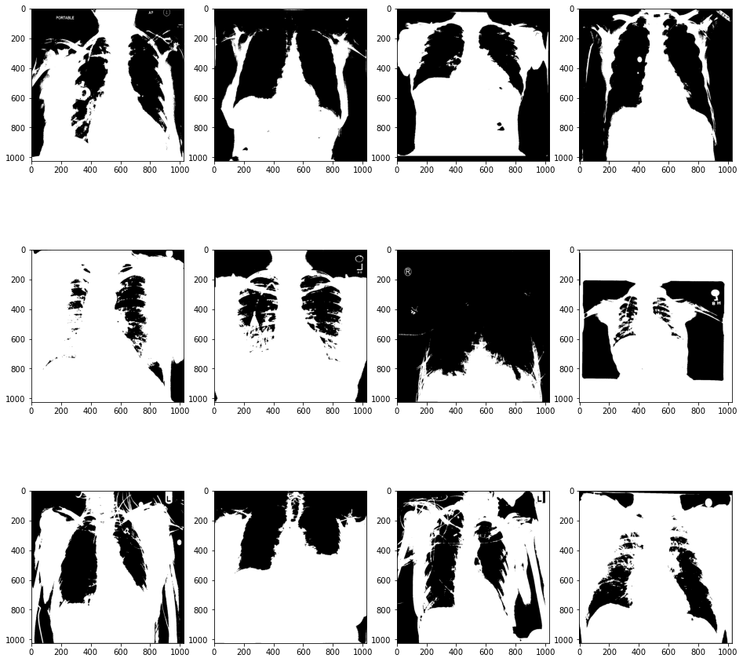

```python
penu_threshold = 0.55
fig, m_axs = plt.subplots(3,4, figsize = (16, 16))
m_axs = m_axs.flatten()

for img, ax in zip(imgs, m_axs):
    path = find_path(img)
    img = plt.imread(path)
    bin_img = (img > penu_threshold) * 255
    ax.imshow(bin_img ,cmap='gray')
```

```python
penumonia_intensities = []
for i in pneumonia_samples['Image Index']:
    my_path = find_path(i)
    if my_path != '':
        img = plt.imread(my_path)
        img_mask = (img > penu_threshold)
        penumonia_intensities.extend(img[img_mask].tolist())
```

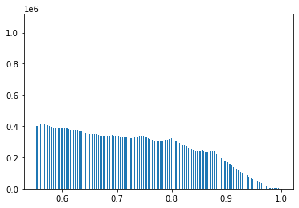

```python
ymin = min(penumonia_intensities)
ymax = max(penumonia_intensities)
y = plt.axis('auto')
y = plt.hist(penumonia_intensities, bins=255, range=(ymin,ymax))
```

```python
sample_df['Atelectasis'] =  sample_df.apply(lambda x: 1 if 'Atelectasis' in x['Finding Labels'] else 0, axis=1)
sample_df['Consolidation'] =  sample_df.apply(lambda x: 1 if 'Consolidation' in x['Finding Labels'] else 0, axis=1)
sample_df['Infiltration'] =  sample_df.apply(lambda x: 1 if 'Infiltration' in x['Finding Labels'] else 0, axis=1)
sample_df['Pneumothorax'] =  sample_df.apply(lambda x: 1 if 'Pneumothorax' in x['Finding Labels'] else 0, axis=1)
sample_df['Edema'] =  sample_df.apply(lambda x: 1 if 'Edema' in x['Finding Labels'] else 0, axis=1)
sample_df['Emphysema'] =  sample_df.apply(lambda x: 1 if 'Emphysema' in x['Finding Labels'] else 0, axis=1)
sample_df['Fibrosis'] =  sample_df.apply(lambda x: 1 if 'Fibrosis' in x['Finding Labels'] else 0, axis=1)
sample_df['Effusion'] =  sample_df.apply(lambda x: 1 if 'Effusion' in x['Finding Labels'] else 0, axis=1)
sample_df['Cardiomegaly'] =  sample_df.apply(lambda x: 1 if 'Cardiomegaly' in x['Finding Labels'] else 0, axis=1)
sample_df['Nodule'] =  sample_df.apply(lambda x: 1 if 'Nodule' in x['Finding Labels'] else 0, axis=1)
sample_df['Mass'] =  sample_df.apply(lambda x: 1 if 'Mass' in x['Finding Labels'] else 0, axis=1)
sample_df['Hernia'] =  sample_df.apply(lambda x: 1 if 'Hernia' in x['Finding Labels'] else 0, axis=1)
```

```python
sample_df['Pleural_thickening'] =  sample_df.apply(lambda x: 1 if 'Pleural_Thickening' in x['Finding Labels'] else 0, axis=1)
```

```python
Atelectasis = sample_df[sample_df['Atelectasis'] == 1]
Atelectasis.shape
```

```
(508, 24)
```

```python
Consolidation = sample_df[sample_df['Consolidation'] == 1]
Consolidation.shape
```

```
(226, 24)
```

```python
Infiltration = sample_df[sample_df['Infiltration'] == 1]
Infiltration.shape
```

```
(967, 24)
```

```python
Pneumothorax = sample_df[sample_df['Pneumothorax'] == 1]
Pneumothorax.shape
```

```
(271, 24)
```

```python
Edema = sample_df[sample_df['Edema'] == 1]
Edema.shape
```

```
(118, 24)
```

```python
Emphysema = sample_df[sample_df['Emphysema'] == 1]
Emphysema.shape
```

```
(127, 24)
```

```python
Fibrosis = sample_df[sample_df['Fibrosis'] == 1]
Fibrosis.shape
```

```
(84, 24)
```

```python
Effusion = sample_df[sample_df['Effusion'] == 1]
Effusion.shape
```

```
(644, 24)
```

```python
Pleural_thickening = sample_df[sample_df['Pleural_thickening'] == 1]
Pleural_thickening.shape
```

```
(176, 24)
```

```python
Cardiomegaly = sample_df[sample_df['Cardiomegaly'] == 1]
Cardiomegaly.shape
```

```
(141, 24)
```

```python
Nodule = sample_df[sample_df['Nodule'] == 1]
Nodule.shape
```

```
(313, 24)
```

```python
Mass = sample_df[sample_df['Mass'] == 1]
Mass.shape
```

```
(284, 24)
```

```python
Hernia = sample_df[sample_df['Hernia'] == 1]
Hernia.shape
```

```
(13, 24)
```

```python
others_threshold = 0.55
other_intensities = {}
other_intensities['Atelectasis'] = []
for i in Atelectasis.sample(62)['Image Index']:
    my_path = find_path(i)
    if my_path != '':
        img = plt.imread(my_path)
        img_mask = (img > others_threshold)
        other_intensities['Atelectasis'].extend(img[img_mask].tolist())
```

```python
other_intensities['Consolidation'] = []
for i in Atelectasis.sample(62)['Image Index']:
    my_path = find_path(i)
    if my_path != '':
        img = plt.imread(my_path)
        img_mask = (img > others_threshold)
        other_intensities['Consolidation'].extend(img[img_mask].tolist())
```

```python
other_intensities['Infiltration'] = []
for i in Atelectasis.sample(62)['Image Index']:
    my_path = find_path(i)
    if my_path != '':
        img = plt.imread(my_path)
        img_mask = (img > others_threshold)
        other_intensities['Infiltration'].extend(img[img_mask].tolist())
```

```python
other_intensities['Pneumothorax'] = []
for i in Atelectasis.sample(62)['Image Index']:
    my_path = find_path(i)
    if my_path != '':
        img = plt.imread(my_path)
        img_mask = (img > others_threshold)
        other_intensities['Pneumothorax'].extend(img[img_mask].tolist())
```

```python
other_intensities['Edema'] = []
for i in Atelectasis.sample(62)['Image Index']:
    my_path = find_path(i)
    if my_path != '':
        img = plt.imread(my_path)
        img_mask = (img > others_threshold)
        other_intensities['Edema'].extend(img[img_mask].tolist())
```

```python
other_intensities['Emphysema'] = []
for i in Atelectasis.sample(62)['Image Index']:
    my_path = find_path(i)
    if my_path != '':
        img = plt.imread(my_path)
        img_mask = (img > others_threshold)
        other_intensities['Emphysema'].extend(img[img_mask].tolist())
```

```python
other_intensities['Fibrosis'] = []
for i in Atelectasis.sample(62)['Image Index']:
    my_path = find_path(i)
    if my_path != '':
        img = plt.imread(my_path)
        img_mask = (img > others_threshold)
        other_intensities['Fibrosis'].extend(img[img_mask].tolist())
```

```python
other_intensities['Effusion'] = []
for i in Atelectasis.sample(62)['Image Index']:
    my_path = find_path(i)
    if my_path != '':
        img = plt.imread(my_path)
        img_mask = (img > others_threshold)
        other_intensities['Effusion'].extend(img[img_mask].tolist())
```

```python
other_intensities['Pleural_thickening'] = []
for i in Atelectasis.sample(62)['Image Index']:
    my_path = find_path(i)
    if my_path != '':
        img = plt.imread(my_path)
        img_mask = (img > others_threshold)
        other_intensities['Pleural_thickening'].extend(img[img_mask].tolist())
```

```python
other_intensities['Cardiomegaly'] = []
for i in Atelectasis.sample(62)['Image Index']:
    my_path = find_path(i)
    if my_path != '':
        img = plt.imread(my_path)
        img_mask = (img > others_threshold)
        other_intensities['Cardiomegaly'].extend(img[img_mask].tolist())
```

```python
other_intensities['Nodule'] = []
for i in Atelectasis.sample(62)['Image Index']:
    my_path = find_path(i)
    if my_path != '':
        img = plt.imread(my_path)
        img_mask = (img > others_threshold)
        other_intensities['Nodule'].extend(img[img_mask].tolist())
```

```python
other_intensities['Mass'] = []
for i in Atelectasis.sample(62)['Image Index']:
    my_path = find_path(i)
    if my_path != '':
        img = plt.imread(my_path)
        img_mask = (img > others_threshold)
        other_intensities['Mass'].extend(img[img_mask].tolist())
```

##### I will ignore the Hernia because the cases are too little

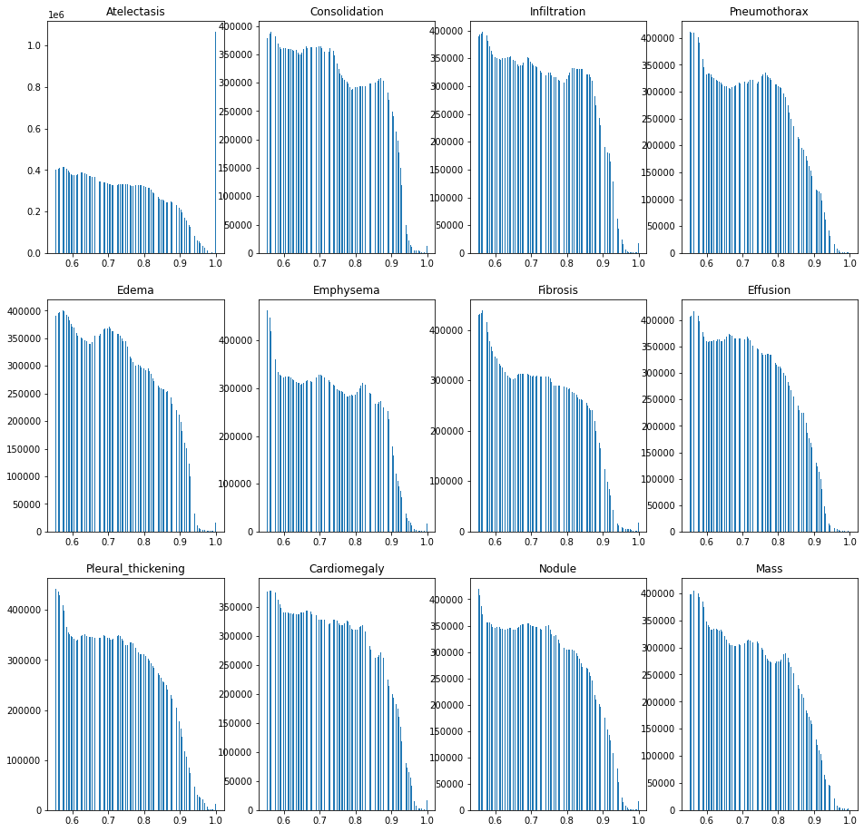

```python
intensities = len(other_intensities)
fig, m_axs = plt.subplots(3,4, figsize = (16, 16))
m_axs = m_axs.flatten()

for i in range(12):
    m_axs[i].hist(other_intensities[str(list(other_intensities)[i])], bins=255)
    m_axs[i].set_title(str(list(other_intensities)[i]))
plt.show()
```

#### The plot of the pneumonia images displaying the y axis scaled, but anyway, from testing the threshold and the intensities

#### plot, we observe that there is no much difference between images with finding(penumonia) and withoud findings. Taht will

#### make setting our model weights a little difficult.

```python
!ls /data
```

```
ARXIV_V5_CHESTXRAY.pdf	images_002  images_007	images_012
BBox_List_2017.csv	images_003  images_008	LOG_CHESTXRAY.pdf
Data_Entry_2017.csv	images_004  images_009	README_CHESTXRAY.pdf
FAQ_CHESTXRAY.pdf	images_005  images_010	test_list.txt
images_001		images_006  images_011	train_val_list.txt
```

```python
test_2 = plt.imread('/data/images_011/images/00027977_000.png')
```

```python
pneumonia_samples.shape
```

```
(62, 12)
```